# CSR Naloxone Standing Order Project - Data Cleaning, Wrangling, and Exporation (eventually)

STAT 245, Fall 2020 (Group Members: Nana Ama Baidoo, Alex Visser, Joshua Ridder, Joseph Jinn)

October 23, 2020

Note to self: Run “remotes::install_github(‘ProjectMOSAIC/ggformula’)” to install development version of ggformula.

```r
# sessionInfo()
```

#### Another dataset to compare agains for our results with CDC Wonder aggregated data statistics.

```r
vssr <- read_csv("datasets\\VSRR_Provisional_Drug_Overdose_Death_Counts.csv")
```

```r
glimpse(vssr)
```

```
## Rows: 34,398
## Columns: 12
## $ State                           <chr> "AK", "AK", "AK", "AK", "AK", "AK",...
## $ Year                            <dbl> 2015, 2015, 2015, 2015, 2015, 2015,...
## $ Month                           <chr> "April", "April", "April", "April",...
## $ Period                          <chr> "12 month-ending", "12 month-ending...
## $ Indicator                       <chr> "Percent with drugs specified", "Na...
## $ `Data Value`                    <dbl> 88.09524, NA, NA, NA, 126.00000, NA...
## $ `Percent Complete`              <dbl> 100, 100, 100, 100, 100, 100, 100, ...
## $ `Percent Pending Investigation` <dbl> 0, 0, 0, 0, 0, 0, 0, 0, 0, 0, 0, 0,...
## $ `State Name`                    <chr> "Alaska", "Alaska", "Alaska", "Alas...
## $ Footnote                        <chr> "Numbers may differ from published ...
## $ `Footnote Symbol`               <chr> "**", "**", "**", "**", "**", "**",...
## $ `Predicted Value`               <dbl> NA, NA, NA, NA, 126, NA, NA, NA, NA...
```

```r
summary(vssr)
```

```
##     State                Year         Month              Period
##  Length:34398       Min.   :2015   Length:34398       Length:34398
##  Class :character   1st Qu.:2016   Class :character   Class :character
##  Mode  :character   Median :2017   Mode  :character   Mode  :character
##                     Mean   :2017
##                     3rd Qu.:2018
##                     Max.   :2020
##
##   Indicator           Data Value        Percent Complete
##  Length:34398       Min.   :     10.0   Min.   : 98.9
##  Class :character   1st Qu.:     92.8   1st Qu.:100.0
##  Mode  :character   Median :    286.0   Median :100.0
##                     Mean   :  13497.1   Mean   :100.0
##                     3rd Qu.:   1024.0   3rd Qu.:100.0
##                     Max.   :2892170.0   Max.   :100.0
##                     NA's   :6510        NA's   :96
##  Percent Pending Investigation  State Name          Footnote
##  Min.   :0.00000               Length:34398       Length:34398
##  1st Qu.:0.01772               Class :character   Class :character
##  Median :0.04605               Mode  :character   Mode  :character
##  Mean   :0.12086
##  3rd Qu.:0.16124
##  Max.   :1.41157
##
##  Footnote Symbol    Predicted Value
##  Length:34398       Min.   : 10.0
##  Class :character   1st Qu.: 71.0
##  Mode  :character   Median :203.0
##                     Mean   :274.9
##                     3rd Qu.:394.0
##                     Max.   :999.0
##                     NA's   :16808
```

```r
head(vssr, 5)
```

```
## # A tibble: 5 x 12
##   State  Year Month Period Indicator `Data Value` `Percent Comple~
##   <chr> <dbl> <chr> <chr>  <chr>            <dbl>            <dbl>
## 1 AK     2015 April 12 mo~ Percent ~         88.1              100
## 2 AK     2015 April 12 mo~ Natural,~         NA                100
## 3 AK     2015 April 12 mo~ Natural ~         NA                100
## 4 AK     2015 April 12 mo~ Psychost~         NA                100
## 5 AK     2015 April 12 mo~ Number o~        126                100
## # ... with 5 more variables: `Percent Pending Investigation` <dbl>, `State
## #   Name` <chr>, Footnote <chr>, `Footnote Symbol` <chr>, `Predicted
## #   Value` <dbl>
```

#### Test that we can import CDC Wonder query files that have been converted to CSV manually.

**TODO: Learn how to import flat text files into R, parse them into a dataframe, and export back out as a CSV.** Note: I know enough to do this in Python, but not R yet. Will need to loook into the tutorials on the course website.

```r
agg1 <- read_csv("datasets\\Underlying_Cause_of_Death_1999-2018.csv")
```

```r
glimpse(agg1)
```

```
## Rows: 511
## Columns: 9
## $ `2013 Urbanization`      <chr> "Large Central Metro", "Large Central Metr...
## $ `2013 Urbanization Code` <dbl> 1, 1, 1, 1, 1, 1, 1, 1, 1, 1, 1, 1, 1, 1, ...
## $ Race                     <chr> "American Indian or Alaska Native", "Ameri...
## $ `Race Code`              <chr> "1002-5", "1002-5", "1002-5", "1002-5", "1...
## $ Year                     <dbl> 1999, 2000, 2001, 2002, 2003, 2004, 2005, ...
## $ `Year Code`              <dbl> 1999, 2000, 2001, 2002, 2003, 2004, 2005, ...
## $ Deaths                   <dbl> 1566, 1660, 1728, 1739, 1904, 1869, 1963, ...
## $ Population               <dbl> 696733, 725867, 771337, 805848, 843939, 88...
## $ `Crude Rate`             <dbl> 224.8, 228.7, 224.0, 215.8, 225.6, 211.1, ...
```

```r
head(agg1)
```

```
## # A tibble: 6 x 9
##   `2013 Urbanizat~ `2013 Urbanizat~ Race  `Race Code`  Year `Year Code` Deaths
##   <chr>                       <dbl> <chr> <chr>       <dbl>       <dbl>  <dbl>
## 1 Large Central M~                1 Amer~ 1002-5       1999        1999   1566
## 2 Large Central M~                1 Amer~ 1002-5       2000        2000   1660
## 3 Large Central M~                1 Amer~ 1002-5       2001        2001   1728
## 4 Large Central M~                1 Amer~ 1002-5       2002        2002   1739
## 5 Large Central M~                1 Amer~ 1002-5       2003        2003   1904
## 6 Large Central M~                1 Amer~ 1002-5       2004        2004   1869
## # ... with 2 more variables: Population <dbl>, `Crude Rate` <dbl>
```

```r
agg2 <- read_csv("datasets\\Underlying_Cause_of_Death_1999-2018_2.csv")
```

```r
glimpse(agg2)
```

```
## Rows: 1,673
## Columns: 11
## $ State                             <chr> "Michigan", "Michigan", "Michigan...
## $ `State Code`                      <dbl> 26, 26, 26, 26, 26, 26, 26, 26, 2...
## $ County                            <chr> "Alcona County, MI", "Alcona Coun...
## $ `County Code`                     <dbl> 26001, 26001, 26003, 26005, 26005...
## $ `Drug/Alcohol Induced Cause`      <chr> "All other non-drug and non-alcoh...
## $ `Drug/Alcohol Induced Cause Code` <chr> "O9", "O9", "O9", "A9", "O9", "O9...
## $ `Cause of death`                  <chr> "Atherosclerotic heart disease", ...
## $ `Cause of death Code`             <chr> "I25.1", "J44.9", "F03", "K70.3",...
## $ Deaths                            <dbl> 10, 18, 10, 12, 15, 12, 64, 11, 1...
## $ Population                        <dbl> 10362, 10362, 9097, 117327, 11732...
## $ `Crude Rate`                      <chr> "Unreliable", "Unreliable", "Unre...
```

```r
head(agg2)
```

```
## # A tibble: 6 x 11
##   State `State Code` County `County Code` `Drug/Alcohol I~ `Drug/Alcohol I~
##   <chr>        <dbl> <chr>          <dbl> <chr>            <chr>
## 1 Mich~           26 Alcon~         26001 All other non-d~ O9
## 2 Mich~           26 Alcon~         26001 All other non-d~ O9
## 3 Mich~           26 Alger~         26003 All other non-d~ O9
## 4 Mich~           26 Alleg~         26005 All other alcoh~ A9
## 5 Mich~           26 Alleg~         26005 All other non-d~ O9
## 6 Mich~           26 Alleg~         26005 All other non-d~ O9
## # ... with 5 more variables: `Cause of death` <chr>, `Cause of death
## #   Code` <chr>, Deaths <dbl>, Population <dbl>, `Crude Rate` <chr>
```

Looks like there’s not initial issues with importing the CSV’s we created from flat text file from the CDC Wonder data queries.

#### EDA

**Note: The goal of our service-learning project is to look through as many different combinations of aggregate statistics as possible to identify relevant trends and patterns. As such, there’s no one “fixed” dataset we are working with, just experimentation with many different aggregate queries.**

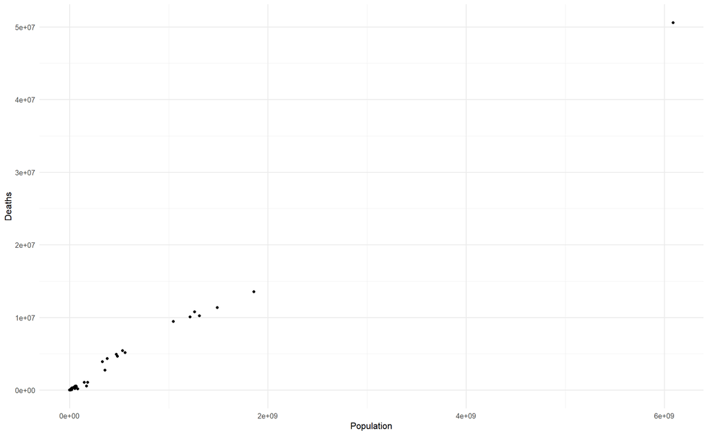

```r
gf_point(Deaths ~ Population, data = agg1)
```

```r
agg1_modified <- agg1 %>% mutate(YearFactor = factor(agg1$Year), Urbanization2013Factor = factor(agg1$`2013 Urbanization`))
```

```r
glimpse(agg1_modified)
```

```
## Rows: 511
## Columns: 11
## $ `2013 Urbanization`      <chr> "Large Central Metro", "Large Central Metr...
## $ `2013 Urbanization Code` <dbl> 1, 1, 1, 1, 1, 1, 1, 1, 1, 1, 1, 1, 1, 1, ...
## $ Race                     <chr> "American Indian or Alaska Native", "Ameri...
## $ `Race Code`              <chr> "1002-5", "1002-5", "1002-5", "1002-5", "1...
## $ Year                     <dbl> 1999, 2000, 2001, 2002, 2003, 2004, 2005, ...
## $ `Year Code`              <dbl> 1999, 2000, 2001, 2002, 2003, 2004, 2005, ...
## $ Deaths                   <dbl> 1566, 1660, 1728, 1739, 1904, 1869, 1963, ...
## $ Population               <dbl> 696733, 725867, 771337, 805848, 843939, 88...
## $ `Crude Rate`             <dbl> 224.8, 228.7, 224.0, 215.8, 225.6, 211.1, ...
## $ YearFactor               <fct> 1999, 2000, 2001, 2002, 2003, 2004, 2005, ...
## $ Urbanization2013Factor   <fct> Large Central Metro, Large Central Metro, ...
```

```r
agg1_modified_noNAs <- drop_na(agg1_modified)
```

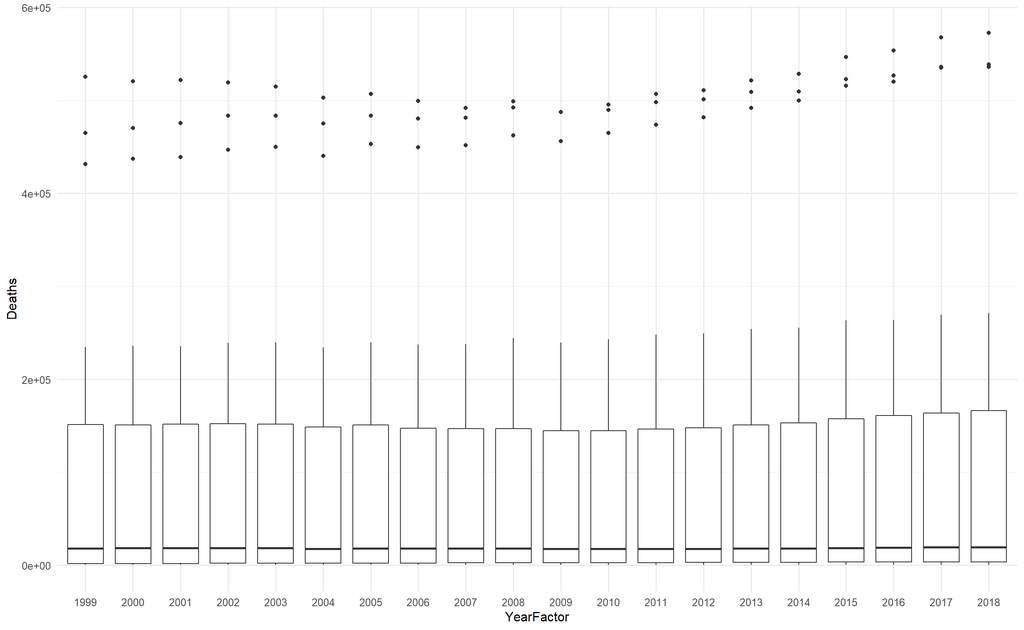

```r
gf_boxplot(Deaths ~ YearFactor, data = agg1_modified_noNAs) #+ coord_flip()
```

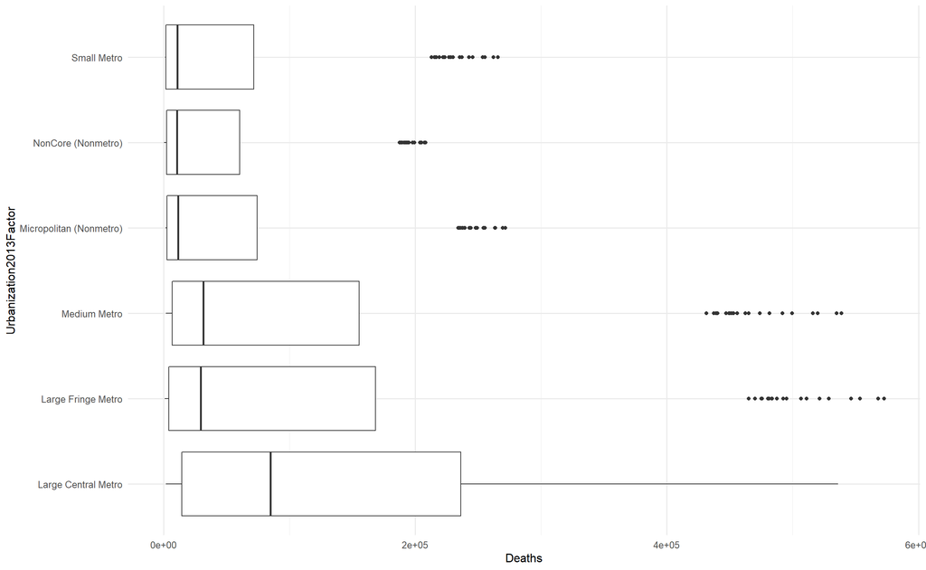

```r
gf_boxplot(Deaths ~ Urbanization2013Factor, data = agg1_modified_noNAs) + coord_flip()
```

```r
glimpse(agg2)
```

```
## Rows: 1,673
## Columns: 11
## $ State                             <chr> "Michigan", "Michigan", "Michigan...
## $ `State Code`                      <dbl> 26, 26, 26, 26, 26, 26, 26, 26, 2...
## $ County                            <chr> "Alcona County, MI", "Alcona Coun...
## $ `County Code`                     <dbl> 26001, 26001, 26003, 26005, 26005...
## $ `Drug/Alcohol Induced Cause`      <chr> "All other non-drug and non-alcoh...
## $ `Drug/Alcohol Induced Cause Code` <chr> "O9", "O9", "O9", "A9", "O9", "O9...
## $ `Cause of death`                  <chr> "Atherosclerotic heart disease", ...
## $ `Cause of death Code`             <chr> "I25.1", "J44.9", "F03", "K70.3",...
## $ Deaths                            <dbl> 10, 18, 10, 12, 15, 12, 64, 11, 1...
## $ Population                        <dbl> 10362, 10362, 9097, 117327, 11732...
## $ `Crude Rate`                      <chr> "Unreliable", "Unreliable", "Unre...
```

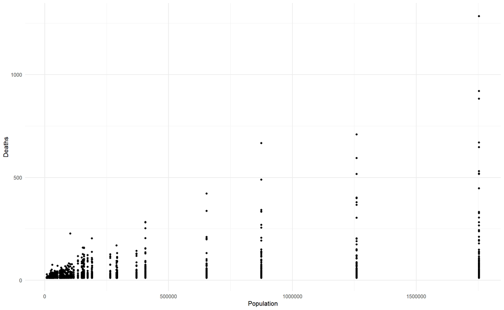

```r
gf_point(Deaths ~ Population, data = agg2)
```

```r
agg2_modified <- agg2 %>% mutate(CountyFactor = factor(agg2$County),
                                 CauseOfDeathFactor = factor(agg2$`Cause of death`),
                                 DrugAlcoholInducedCauseFactor = factor(agg2$`Drug/Alcohol Induced Cause`))
```

```r
glimpse(agg2_modified)
```

```
## Rows: 1,673
## Columns: 14
## $ State                             <chr> "Michigan", "Michigan", "Michigan...
## $ `State Code`                      <dbl> 26, 26, 26, 26, 26, 26, 26, 26, 2...
## $ County                            <chr> "Alcona County, MI", "Alcona Coun...
## $ `County Code`                     <dbl> 26001, 26001, 26003, 26005, 26005...
## $ `Drug/Alcohol Induced Cause`      <chr> "All other non-drug and non-alcoh...
## $ `Drug/Alcohol Induced Cause Code` <chr> "O9", "O9", "O9", "A9", "O9", "O9...
## $ `Cause of death`                  <chr> "Atherosclerotic heart disease", ...
## $ `Cause of death Code`             <chr> "I25.1", "J44.9", "F03", "K70.3",...
## $ Deaths                            <dbl> 10, 18, 10, 12, 15, 12, 64, 11, 1...
## $ Population                        <dbl> 10362, 10362, 9097, 117327, 11732...
## $ `Crude Rate`                      <chr> "Unreliable", "Unreliable", "Unre...
## $ CountyFactor                      <fct> "Alcona County, MI", "Alcona Coun...
## $ CauseOfDeathFactor                <fct> "Atherosclerotic heart disease", ...
## $ DrugAlcoholInducedCauseFactor     <fct> All other non-drug and non-alcoho...
```

```r
agg1_modified_noNAs <- drop_na(agg1_modified)
```

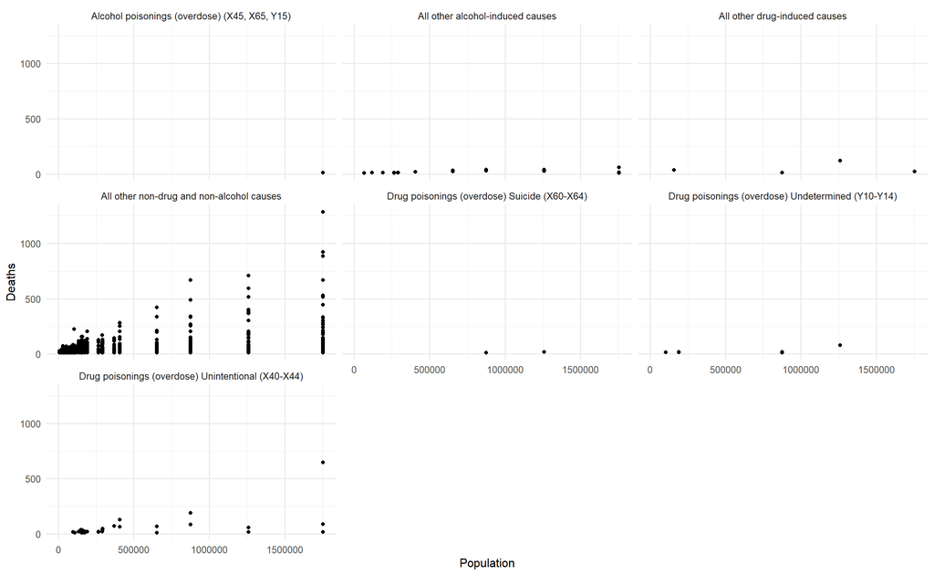

```r
gf_point(Deaths ~ Population | DrugAlcoholInducedCauseFactor, data = agg2_modified)
```

```r
unique(agg2_modified$County)
```

```
##  [1] "Alcona County, MI"         "Alger County, MI"
##  [3] "Allegan County, MI"        "Alpena County, MI"
##  [5] "Antrim County, MI"         "Arenac County, MI"
##  [7] "Baraga County, MI"         "Barry County, MI"
##  [9] "Bay County, MI"            "Benzie County, MI"
## [11] "Berrien County, MI"        "Branch County, MI"
## [13] "Calhoun County, MI"        "Cass County, MI"
## [15] "Charlevoix County, MI"     "Cheboygan County, MI"
## [17] "Chippewa County, MI"       "Clare County, MI"
## [19] "Clinton County, MI"        "Crawford County, MI"
## [21] "Delta County, MI"          "Dickinson County, MI"
## [23] "Eaton County, MI"          "Emmet County, MI"
## [25] "Genesee County, MI"        "Gladwin County, MI"
## [27] "Gogebic County, MI"        "Grand Traverse County, MI"
## [29] "Gratiot County, MI"        "Hillsdale County, MI"
```

[output cut: 25 more lines]

```r
unique(agg2_modified$CauseOfDeathFactor)
```

```
##   [1] Atherosclerotic heart disease
##   [2] Chronic obstructive pulmonary disease, unspecified
##   [3] Unspecified dementia
##   [4] Alcoholic cirrhosis of liver
##   [5] Colon, unspecified - Malignant neoplasms
##   [6] Pancreas, unspecified - Malignant neoplasms
##   [7] Bronchus or lung, unspecified - Malignant neoplasms
##   [8] Malignant neoplasm of prostate
##   [9] Non-insulin-dependent diabetes mellitus, without complications
##  [10] Unspecified diabetes mellitus, without complications
##  [11] Parkinson disease
##  [12] Alzheimer disease, unspecified
##  [13] Acute myocardial infarction, unspecified
##  [14] Atherosclerotic cardiovascular disease, so described
##  [15] Ischaemic cardiomyopathy
```

[output cut: 195 more lines]